# Practical Machine Learning Project

Eric VACHON

September 2015

The goal of this project is to predict the way (**“classe”** variable in the training set) the participants performed barbell fits. To do this we can use any of the variables of the training set. The data set came from the Weight Lifting Exercises Dataset : [Velloso, E.; Bulling, A.; Gellersen, H.; Ugulino, W.; Fuks, H. Qualitative Activity Recognition of Weight Lifting Exercises. Proceedings of 4th International Conference in Cooperation with SIGCHI (Augmented Human ’13) . Stuttgart, Germany: ACM SIGCHI, 2013.](http://groupware.les.inf.puc-rio.br/har#weight_lifting_exercises)

### 1. Analyse and Methodology.

In first i analysed the raw data and summary them and i did a histogram of the classe variable to know if they are well balanced or not.  
Next i studied the features and cleaned them by removing the correlated features and dummy the factors features before splitting the training (**our** test set and **our** train set) and fitting my data set. I did a cross validation before applying the model to my test set and do a confusion matrix to score my model. Finally i applied this model to predict the classes of 20 samples (test set)

### 2. Loading libraries and Input Data.

In first set the seed for reproducibility, then load the libraries then the data set and the test set.

```r
set.seed(123)
library(caret);library(ggplot2);library(RCurl);library(corrplot);library(reshape2);library(dplyr)
loadCSV <- function(URL) {
        csv <- tryCatch({read.csv(text=getURL(URL,ssl.verifypeer=0L, followlocation=1L))},
                         error=function(cond) {return(read.csv(URL))})
        return(csv)
}

trainingSet <- loadCSV("https://d396qusza40orc.cloudfront.net/predmachlearn/pml-training.csv")
testSet     <- loadCSV("https://d396qusza40orc.cloudfront.net/predmachlearn/pml-testing.csv")
```

By summary the training set (*nrow(trainingSet)* and *names(trainingSet)*), we can know that wr have 19622 samples and 160 features : 1 id (X : the sample number) and 158 to explain the “classe” variables (A,B,C,D or E).

Let’s take a look at the histogram of the classe variable

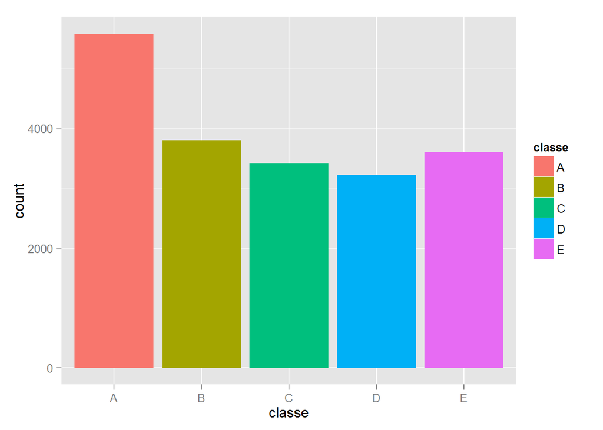

```r
ggplot(trainingSet) + geom_histogram(aes(x = classe, fill= classe))
```

We can see that the classes are quit well balanced (order of 10<sup>3</sup>) so we can use a *random forest model*.

### 3. Features selection.

In this study we apply the transformation on both trainng and test set. We are going to remove features which are not relevant because they have less power of prediction or add noise.

First we are going to remove timestamp feature (noise).

```r
lTimeStamp <- lTimeStamp <- names(trainingSet[grep("timestamp", names(trainingSet))])
train      <- trainingSet[,!(names(trainingSet) %in% lTimeStamp)]
test       <- testSet[,!(names(testSet) %in% lTimeStamp)]
```

Next we removed the id (X) of each sample (unique so no power of explication).

```r
train$X <- NULL
test$X  <- NULL
```

Next we removed the feature with more than 95% of NA or null string (’’) (less prediction power).

```r
colNA  <- c(names(train[apply(train, 2,function(x) length(which(is.na(x)))>=(0.95*nrow(train)))]))
train  <- train[,!(names(train) %in% colNA)]
test   <- test[,!(names(test) %in% colNA)]
lEmpty <- c(names(train[apply(train, 2, function(x) length(which(x==''))>=(0.95*nrow(train)))]))
train  <- train[,!(names(train) %in% lEmpty)]
test   <- test[,!(names(test) %in% lEmpty)]
```

### 4. Features cleanning and vectorization.

We can see that the new_window variable is “yes” or “no” so we transforme it into binary variable (0 or 1).

```r
train$new_window <- as.integer(train$new_window=="yes")
test$new_window  <- as.integer(test$new_window=="yes")
```

Now we made a correlation matrix to determine the most correlated feature (min 90%) and drop them.  
NB: in this study we choosz to use this approch instead of a PCA preprocess.

```r
nonFactorCol <- names(train[sapply(train, function(x) !is.factor(x))])
MCor         <- abs(cor(train[,nonFactorCol],use="pairwise.complete.obs"))
diag(MCor)   <- 0
MCor         <- as.matrix(MCor)
MCor         <- arrange(melt(MCor), abs(value))
MCor         <- subset(MCor, value > 0.9)
colMCor      <- MCor[as.character(MCor$Var1) < as.character(MCor$Var2),]
colMCor      <- as.character(MCor[as.character(MCor$Var1)<as.character(MCor$Var2),"Var1"])
train        <- train[,!(names(train) %in% colMCor)]
test         <- test[,!(names(test) %in% colMCor)]
```

Now we looked at the factor features (categorial features).

```r
factorCol <- names(train[sapply(train, function(x) is.factor(x))])
```

We have two features : user_name and classe what we want to predict, so we are going to create dummy variables with “user_name”

```r
user_name            <- factor(train$user_name)
dummiesUserName      <- data.frame(model.matrix(~user_name-1))
trainDummy           <- cbind(train,dummiesUserName)
trainDummy$user_name <- NULL
user_name            <- factor(test$user_name)
dummiesUserName      <- data.frame(model.matrix(~user_name-1))
testDummy            <- cbind(test,dummiesUserName)
testDummy$user_name  <- NULL
```

We added dummy variables so we must identify the column number of the feature “classe”.

```r
idxClasse <- grep("classe", colnames(trainDummy))
```

And we can look at the final correlation between features.

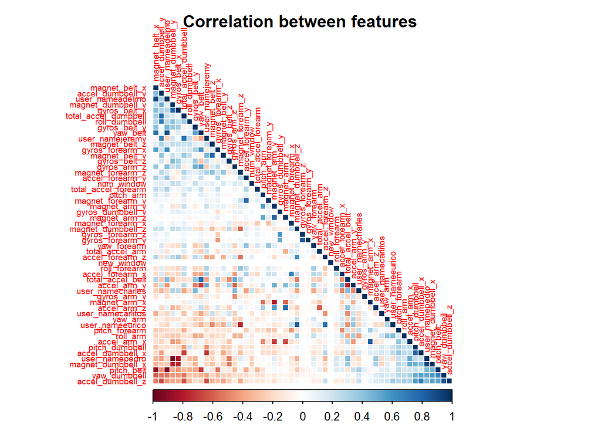

```r
corrplot(cor(trainDummy[,-idxClasse]), order = "FPC", method = "color", type = "lower", tl.cex = 0.6,title="\n\nCorrelation between features" )
```

Here we can see few correlated features but it is not very important because **random forest** doesn’t take care of correlated features.

### 5. Split data train.

Let’s split the train set into **our** train set (80%) and **our** test set (hold_out : 20%) .

```r
inTrain  <- createDataPartition(y=trainDummy$classe, p=.80, list = FALSE)
ourTrain <- trainDummy[inTrain,]
ourTest  <- trainDummy[-inTrain,]
```

### 6. Cross validation on our training set (80% of the original training set).

To train and validate our model we used a kfold cross validation with 5 folds on **our** training set (80% of the given training set, so 15699 samples).

```r
train_control <- trainControl(method="cv", number=5)
```

### 7. Fitting and training on our training set (80% of the original training set).

Now we can fit the model and look at the accurancy on **our** training set.

```r
modelFit     <- train(ourTrain$classe ~ ., method = "rf",data=ourTrain, trControl=train_control)
modelAcc     <- modelFit$results[modelFit$results$mtry==modelFit$bestTune$mtry,]
modelErrRate <- 1 - modelAcc$Accuracy
```

So with the result of this training train model we have an estimate accuracy of about 99.66% so an error rate of 0.34%. Accuracy was used to select the optimal model using the largest value. The final value used for the model was mtry = 27. Finally we ca see that the standard deviation of the accurancy is 0.001. Now we plot the 40 more important features.

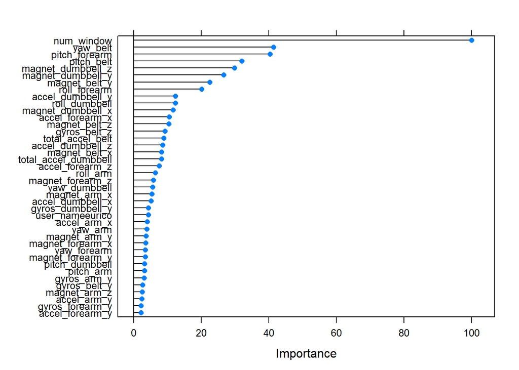

```r
plot(varImp(modelFit), top = 40)
```

### 8. Score, error and validating the model with our test set (20% of the original training set).

To score **our** model we applied it to **our** test set (3923 samples) and looked at the accuray and sensitivity of the prediction. We also did a confusion matrix before ending with the plot results of **our** test set.

```r
testPred        <- predict(modelFit,ourTest)
confMatrix      <- confusionMatrix(ourTest$classe,testPred)
accuracy        <- confMatrix$overall["Accuracy"]
errorRate       <- 1 - accuracy
meanSensitivity <- mean(confMatrix$byClass[,"Sensitivity"])
```

So we have a accuracy of 99.92% so an error rate of 0.08% and a sensitivity (mean of each class) of 99.91%. Now wa present the confusion Matrix in percentage.

```r
round(prop.table(confMatrix$table, margin=2)*100,2)
```

```
##           Reference
## Prediction      A      B      C      D      E
##          A 100.00   0.00   0.00   0.00   0.00
##          B   0.00 100.00   0.00   0.00   0.00
##          C   0.00   0.00  99.56   0.00   0.00
##          D   0.00   0.00   0.44 100.00   0.00
##          E   0.00   0.00   0.00   0.00 100.00
```

And now we plot the test prediction.

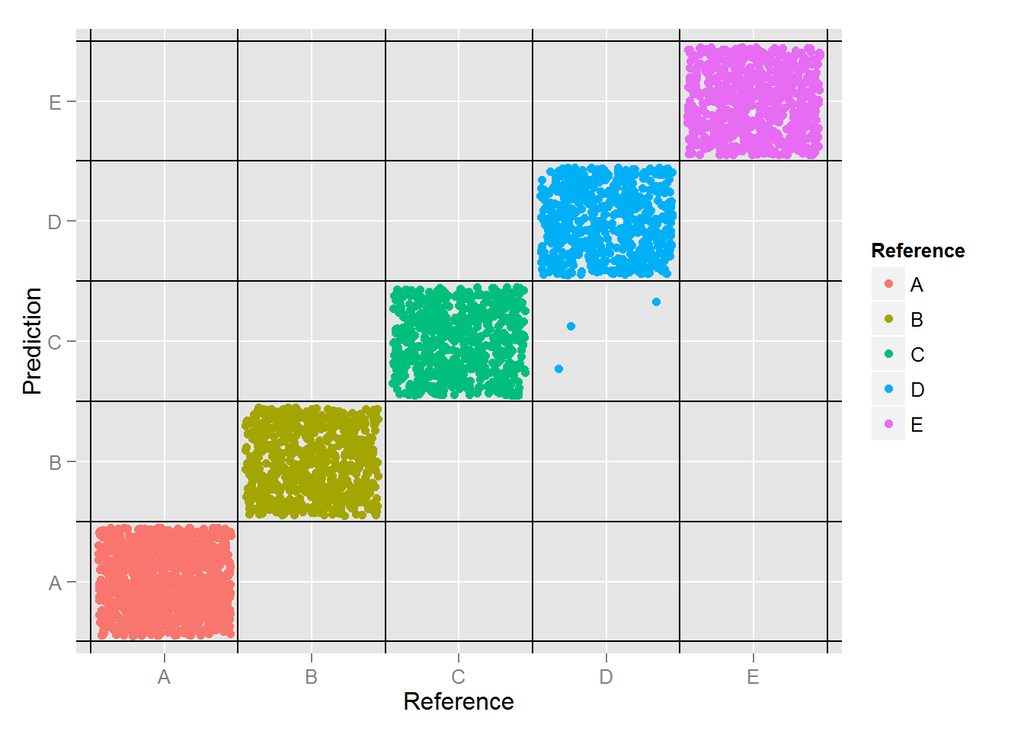

```r
results           <- cbind.data.frame(ourTest$classe,testPred)
colnames(results) <- c("Reference", "Prediction")
p <- ggplot(results, aes(x = Reference, y = Prediction))
p <- p + geom_jitter(position = position_jitter(width = 0.45, height = 0.45), aes(colour = Reference))
for (i in 0:5) {p <- p + geom_abline(intercept=i+0.5,slope=0) + geom_vline(xintercept = i+0.5)}
p
```

### 9. Course predictions.

Last step the prediction of the 20 samples of the coursera course.

```r
predict(modelFit,testDummy)
```

```
##  [1] B A B A A E D B A A B C B A E E A B B B
## Levels: A B C D E
```